# Simulation: Estimating M with One Monotone Anchor per Ordering

Ziang Zhang

## Question

How accurately does the current MPCurver automatic-$M$ workflow recover the number of latent sample orderings when each ordering has one monotone anchor and all remaining trajectories are smooth and nonmonotone?

We fitted all 90 fixed datasets with **MPCurver 0.3.4** using `fit_mpcurve(intrinsic_dim = "auto")`. The final effective $M$ is exact in **88/90 datasets**. The two errors are underestimates in the hardest $M=5$ settings; there are no final overestimates. Mean feature-partition ARI is **0.994**, and mean matched ordering recovery is **0.839**.

## Simulation design

Each dataset contains **300 samples and 60 features**, arranged in balanced groups following **3, 4, or 5 independent latent orderings**. This gives 20, 15, or 12 features per ordering. For sample $i$ and feature $j$,

$$X_{ij}=f_j(t_{i,z_j})+\epsilon_{ij},$$

where $z_j$ identifies the feature’s ordering and the latent positions are independent Uniform$(0,1)$ draws. Within each group, one feature is a monotone anchor. Every other feature follows a random smooth mixture,

$$f_j(t)=\sum_{k=2}^{4}
\frac{a_{jk}\sin(k\pi t)+b_{jk}\cos(k\pi t)}{k^2},$$

where the coefficients are independent standard normal draws. Retained curves have derivatives of both signs on a 1,001-point grid, so every non-anchor trajectory contains at least one change of direction. Each noiseless feature is centered and scaled to sample variance one.

The variance signal-to-noise ratio is **1, 4, or 16**, with **10 independent datasets per condition**. The feature groups are balanced, and the simulation does not include garbage features.

### Simulated trajectories and observations

Figures 1–3 show replicate 1 from every condition. Each row is a true ordering and each column is an SNR setting. Blue shows the monotone anchor; orange and purple show two nonmonotone trajectories in the same group.

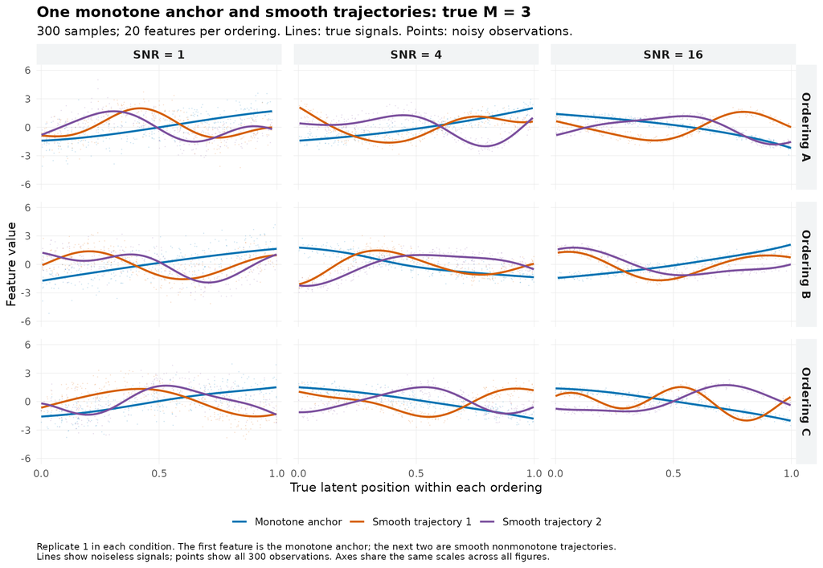

Figure 1. True M = 3: replicate 1 at SNR 1, 4, and 16. Rows identify the three true orderings, each containing 20 features. Lines show one monotone anchor and two nonmonotone noiseless trajectories; points show all 300 noisy observations for each displayed feature.

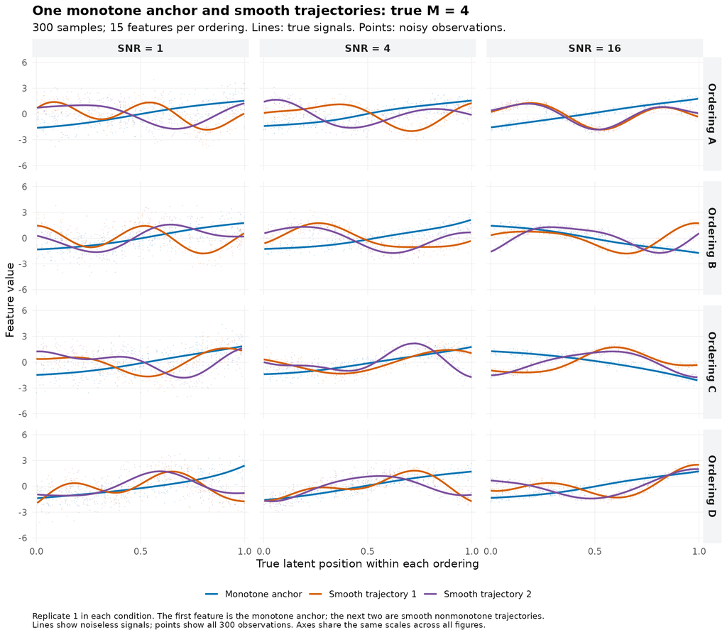

Figure 2. True M = 4: replicate 1 at each SNR. Rows identify the four true orderings, each containing 15 features. Blue lines show monotone anchors; orange and purple lines show two nonmonotone trajectories per ordering.

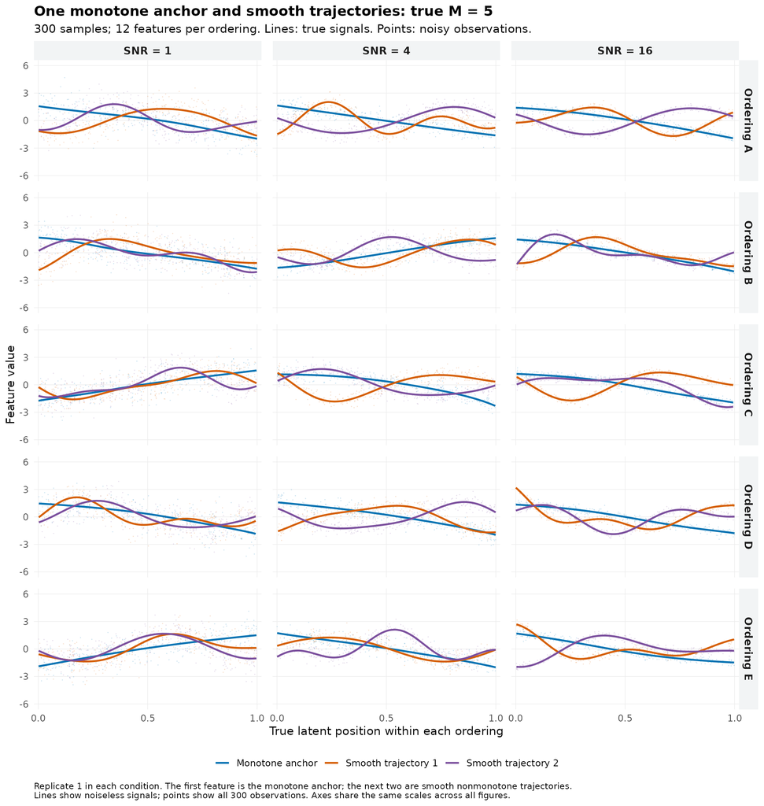

Figure 3. True M = 5: replicate 1 at each SNR. Rows identify the five true orderings, each containing 12 features. Blue lines show monotone anchors; orange and purple lines show two nonmonotone trajectories per ordering.

## Methods

### Automatic dimension initialization

MPCurver 0.3.4 computes a directional nonlinear similarity for every feature pair. One feature is sorted, and the other is regressed on its normalized rank with a natural cubic spline having five fixed degrees of freedom. The score is the proportion of response variance explained; the symmetric similarity is the larger score from the two directions.

Single-linkage clustering considers cuts with at most eight groups. A cut is eligible only when every group contains at least two features. Among eligible cuts, the selected initial $M$ maximizes mean silhouette width. If the selected group sizes are $d_1,\ldots,d_M$, adaptive EB starts with the global assignment probabilities

$$p(z_j=m)=d_m/60.$$

The tree cut therefore initializes the number and relative sizes of the orderings without imposing a hard feature assignment. Adaptive EB may remove components during fitting.

### Ordering and fitting

Isomap is applied independently within every selected feature group to initialize its sample ordering. Coordinate-ascent variational inference (CAVI) then fits 50 position-grid points, a second-order random-walk prior with `ridge = 0`, adaptive cell-position priors, estimated feature-specific noise and smoothness, and annealing from temperature five to one. Convergence requires absolute ELBO change divided by $ND$ below $10^{-6}$, with at most 10,000 sweeps.

The reported **effective M** is the number of components whose mean posterior feature-assignment probability exceeds $10^{-12}$. Feature-group recovery uses the adjusted Rand index (ARI). Ordering recovery matches occupied inferred orderings one-to-one with the true orderings by absolute Spearman correlation, allowing reversal; an unmatched true ordering contributes zero.

All results below use MPCurver **0.3.4**, commit `15f2b0bbe5dfa61cd46da5160b2bc251e75a0475`.

## Recovery of M

The spline-similarity cut selects the true initial $M$ in **88/90 datasets**, with **0 underestimates** and **2 overestimates**. After adaptive EB, the effective $M$ is exact in **88/90**, with **2 underestimates** and **0 overestimates**. Figure 4 reports final exact recovery by condition, Figure 5 compares it with the initial count, and Table 1 gives the overall totals.

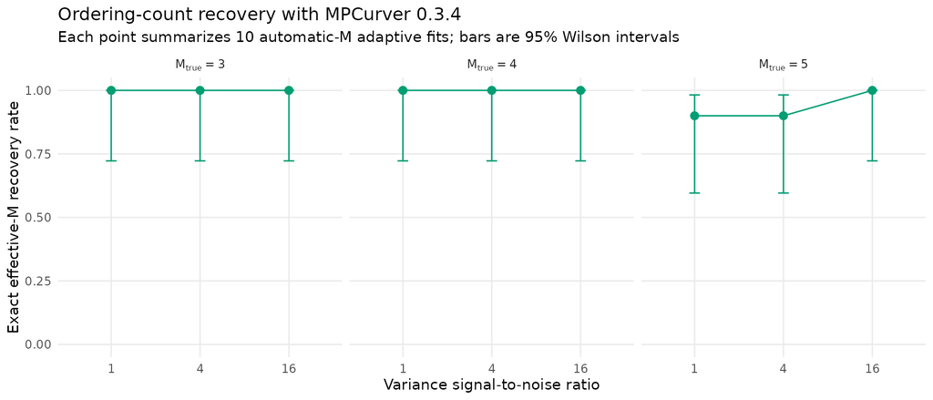

Figure 4. Exact effective-M recovery for MPCurver 0.3.4 automatic-M adaptive fitting. Columns show the generating M. Each point summarizes 10 datasets at the labeled variance SNR; error bars are 95% Wilson intervals.

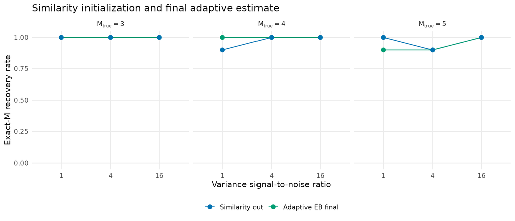

Figure 5. Exact-M recovery at the similarity-cut initialization and after adaptive EB. The initial count is selected by mean silhouette among single-linkage cuts satisfying the minimum cluster size of two; the final count is posterior occupancy after adaptive fitting. Each point summarizes 10 datasets.

The two final errors occur for true $M=5$: one at SNR 1 and one at SNR 4 (Figure 6). Both fits retain four occupied orderings. All datasets with true $M=3$ or $M=4$ are recovered exactly at every SNR.

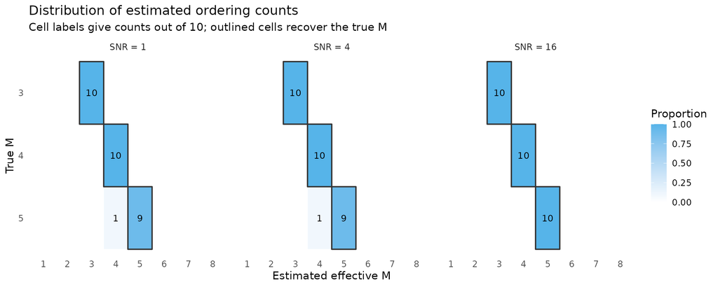

Figure 6. Estimated effective-M distributions from the current package. Panels identify SNR, rows identify the generating M, and columns identify the fitted effective M. Cell labels give counts out of 10 datasets; outlined cells are exact.

Table 1. Overall MPCurver 0.3.4 automatic-M results across the 90 datasets.

| Datasets | Exact M | Underestimates | Overestimates | Mean ARI | Mean ordering score | Median seconds | Warnings |
| --- | --- | --- | --- | --- | --- | --- | --- |
| 90 | 88 | 2 | 0 | 0.994 | 0.839 | 34.65 | 0 |

## Recovery of the underlying structure

The current fit has mean feature-partition ARI **0.994**. Its mean matched ordering score is **0.839**. Table 2 lists every condition. Feature grouping is nearly exact even at SNR 1, whereas estimation of the continuous sample positions is more sensitive to noise (Figure 7).

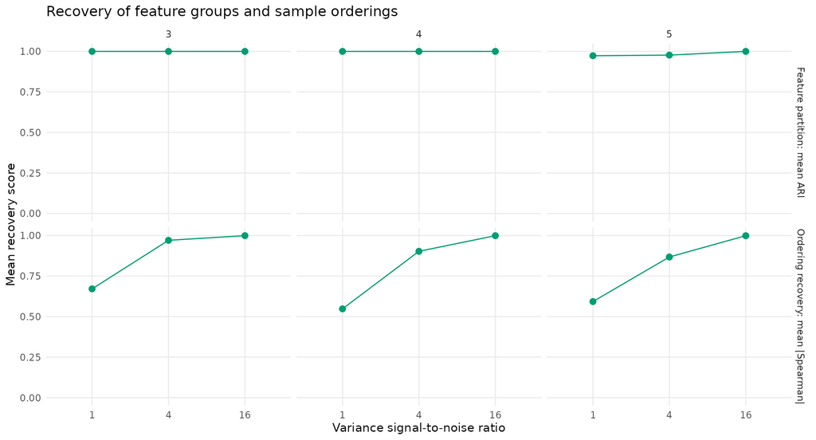

Figure 7. Structural recovery from MPCurver 0.3.4. The top row shows mean feature-partition ARI; the bottom row shows mean absolute Spearman correlation after one-to-one matching of inferred and true orderings. Each point averages 10 datasets.

Table 2. Current-package recovery and runtime by simulation condition.

| True M | SNR | Datasets | Initial M exact | Final M exact | Mean ARI | Mean ordering score | Median seconds |
| --- | --- | --- | --- | --- | --- | --- | --- |
| 3 | 1 | 10 | 10 | 10 | 1.000 | 0.671 | 33.550 |
| 4 | 1 | 10 | 9 | 10 | 1.000 | 0.548 | 38.419 |
| 5 | 1 | 10 | 10 | 9 | 0.973 | 0.593 | 57.888 |
| 3 | 4 | 10 | 10 | 10 | 1.000 | 0.971 | 27.398 |
| 4 | 4 | 10 | 10 | 10 | 1.000 | 0.903 | 32.320 |
| 5 | 4 | 10 | 9 | 9 | 0.977 | 0.868 | 59.992 |
| 3 | 16 | 10 | 10 | 10 | 1.000 | 0.999 | 15.252 |
| 4 | 16 | 10 | 10 | 10 | 1.000 | 0.999 | 26.488 |
| 5 | 16 | 10 | 10 | 10 | 1.000 | 0.999 | 35.086 |

### Representative current-package fits

Figures 8–10 use SNR 4 and replicate 1 for each true $M$. Every panel comes from the MPCurver 0.3.4 automatic-$M$ adaptive fit. The top row displays the simulated trajectories; the bottom row compares true and matched inferred sample positions.

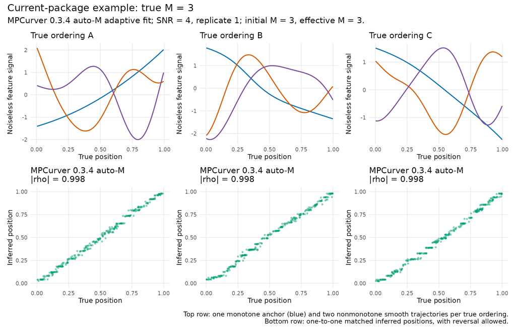

Figure 8. MPCurver 0.3.4 example with true M = 3, SNR 4, and replicate 1. The automatic initializer selects M = 3, adaptive EB retains three occupied orderings, and all three sample orderings are recovered with absolute Spearman correlation about 0.998.

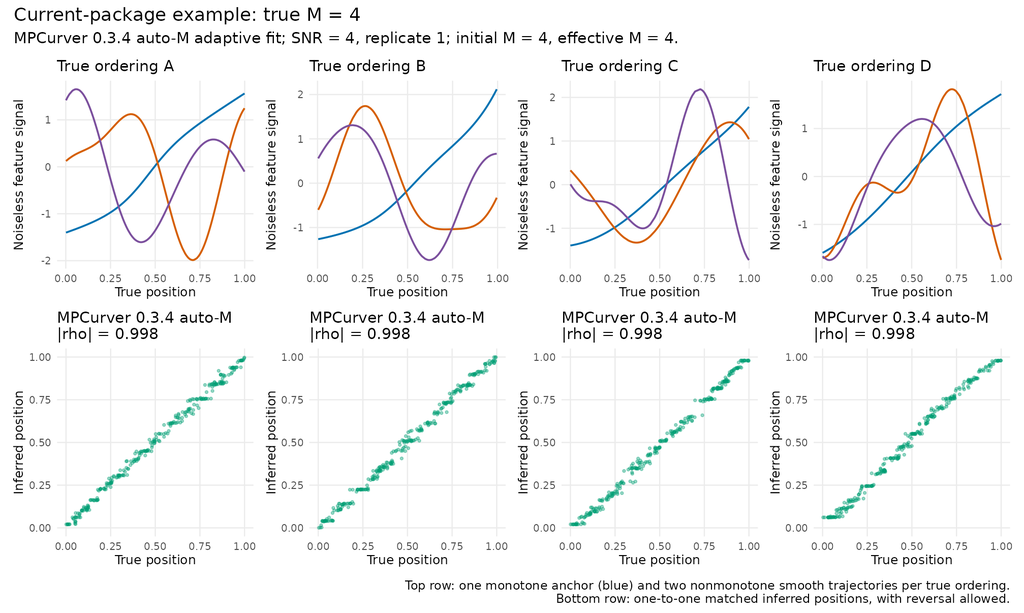

Figure 9. MPCurver 0.3.4 example with true M = 4, SNR 4, and replicate 1. Columns identify true orderings. The bottom row shows their one-to-one matched inferred sample positions from the automatic-M adaptive fit.

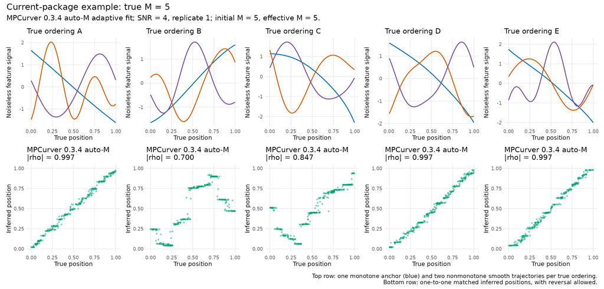

Figure 10. MPCurver 0.3.4 example with true M = 5, SNR 4, and replicate 1. The subtitle reports the initial and final ordering counts; bottom-panel labels give reversal-invariant absolute Spearman correlations.

## Runtime and convergence

All **90 current-package fits** converged without fitting warnings. Median single-thread runtime is **34.6 seconds** per dataset. Runtime (Figure 11) includes similarity calculation, automatic dimension selection, ordering initialization, annealing, and adaptive fitting.

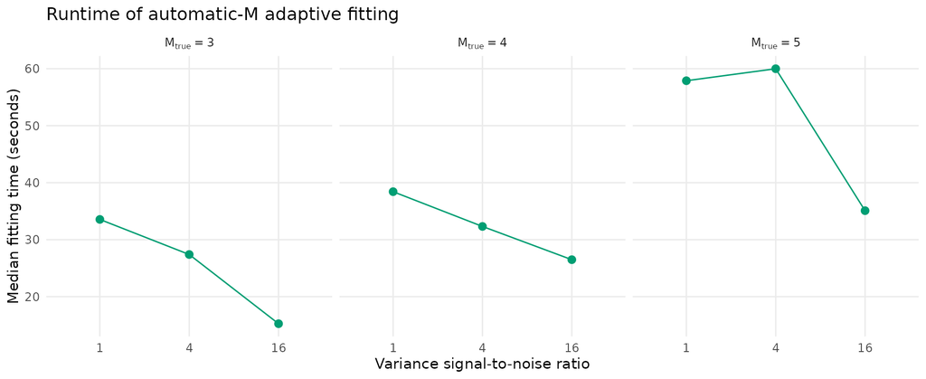

Figure 11. Median single-thread runtime of MPCurver 0.3.4 automatic-M adaptive fitting. Each point summarizes 10 complete fits, including similarity calculation, dimension initialization, and adaptive EB.

## Summary and reproduction

On these balanced one-anchor datasets, the current MPCurver workflow recovers the final effective ordering count in **88/90 datasets** and never overestimates it. The two misses combine two true orderings in the hardest $M=5$ settings. Feature groups remain nearly exact overall; continuous ordering recovery improves sharply with SNR.

This design assumes at least two features per ordering, includes one monotone anchor in every group, and contains no garbage features. The minimum-cluster rule prevents singleton orderings but does not identify unstructured features; that requires a separate background or garbage component.

The [experiment directory](https://github.com/AgueroZZ/InferOrder/tree/master/experiments/estimate_intrinsic_m_smooth_v032/auto_m_v034) contains all 90 fixed inputs, saved fits, validation records, result tables, current-package figures, and reproduction scripts. The frozen MPCurver 0.3.4 source archive has SHA-256 `58d0c99c6170994c82eedba190fb1c28a63eb47530c575705323c3cf3992b7c6`.